# A3: Incarceration

### Introduction

People of colour are incarcerated at far higher rates than other demographics. As such, I will analysis the jail population data to understand the racial disparity present in incarceration trends in the U.S. Specifically, I will analyse the total jail population and compare it across different racial groups. I am analysing this problem in order to highlight racial inequalities in the U.S. criminal justice system.

### Summary Information

This dataset contains observations from 1970 to 2018. The county with the highest jail population is Los Angeles County with 17208 inmates, while the counties with the lowest are Caldwell County, Lyon County, Big Stone County, Stevens County, and Traverse County, with 0 inmates. However, interestingly enough, the average number of white inmates appears to be higher than the average number of Black inmates (117 > 84).

### The Dataset

Who collected the data?  
- U.S. Bureau of Justice Statistics  
How was the data collected or generated?  
- Data was compiled from official records of jail populations  
Why was the data collected?  
- To analyse and monitor trends in jail populations, focusing on racial disparity  
How many observations (rows) are in your data?  
- 153811  
How many features (columns) are in the data?  
- 28  
What, if any, ethical questions or questions of power do you need to consider when working with this data?  
- Firstly, the potential stigmatization of communities is a significant concern. Highlighting high incarceration rates in certain areas can reinforce negative stereotypes and further marginalize already vulnerable populations. It is essential to present data in a way that promotes understanding and compassion rather than judgment. Secondly, inaccurate or incomplete data can lead to misguided policies and interventions that may harm rather than help affected communities. Ensuring that the data is as accurate and comprehensive as possible is crucial for meaningful analysis. Additionally, publicizing trends in incarceration rates can influence public perception and policy in various ways, potentially leading to increased surveillance and policing in specific communities.

What are possible limitations or problems with this data? (at least 200 words)  
- One significant limitation is the presence of missing data. Incomplete records can skew analyses and lead to inaccurate conclusions. Missing data may result from various factors, including administrative errors or lack of reporting from certain jurisdictions. Moving on, different counties may have different definitions and methods for recording jail population data, making it difficult to compare data across regions. Such inconsistencies can make drawing meaningful comparisons and identifying trends hard. Furthermore, the accurate reporting of certain populations is a critical issue. Some groups, particularly marginalized communities, may be underrepresented or overrepresented in the data due to systemic biases in the criminal justice system. This can lead to an incomplete understanding of incarceration trends. Additionally, the dataset may not capture all relevant factors influencing jail populations, such as changes in local policies, economic conditions, and social services availability. Due to these limitations, it is important to interpret the data with caution, and use it with supporting data sources instead of by itself.

### Trends Over Time Chart

I included this chart because it shows how Black and White jail populations changed over time. This chart actually shows that at any given moment, on average there are more White incarcerated people than Black. This is actually very interesting as it is known that people of colour are incarcerated at higher rates. Another thing to notice is that the total jail population appears to be far greater than the sum of the two races analysed. This goes to show that we should consider and analyse other races as well, beyond White and Black.

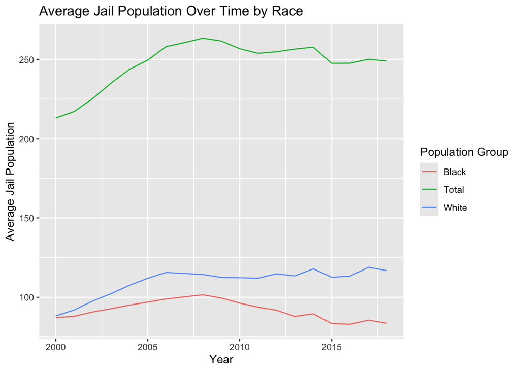

### Variable Comparison Chart

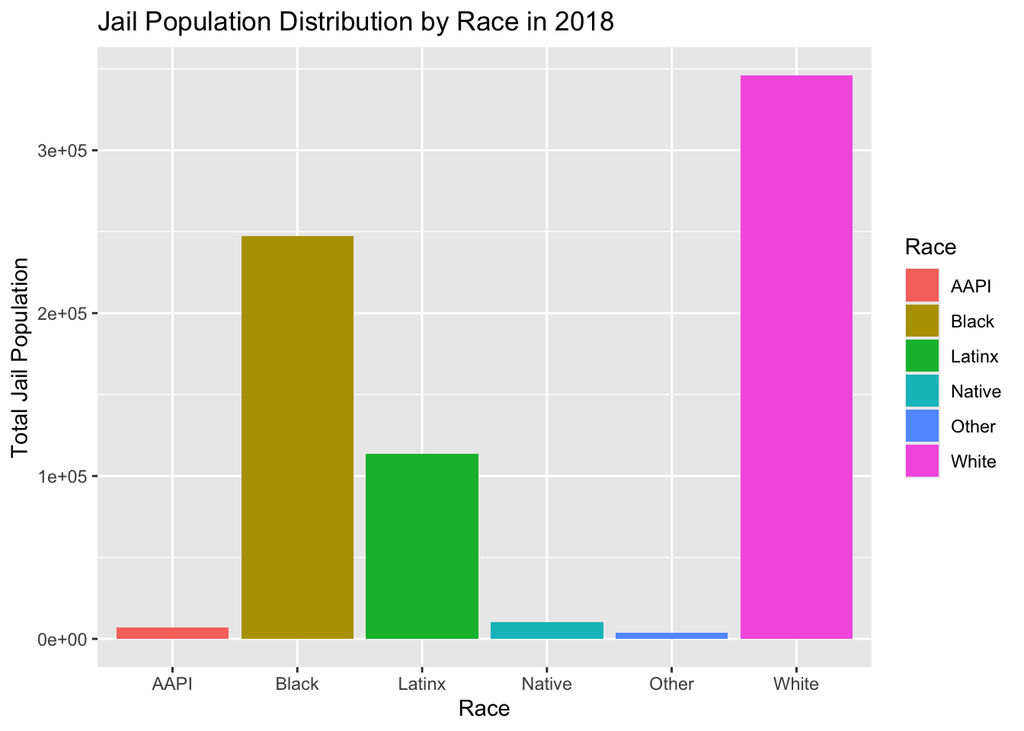

### Map

I included this chart because I was curious to discover whether jail populations changed significantly from state to state. I found that jail populations tend to be higher near the coasts, and near the Southern border. The higher incarceration rates near the Southern border can be explained in some part by the high amount of immigration; however, it is not clear based on the data why the average jail population would be higher near the coasts. The state with the highest jail population appears to be California. It is once again unclear based on the data as to why.

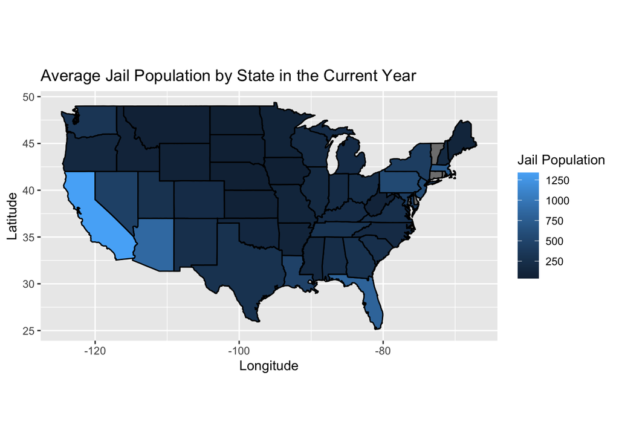